# L1Q6html

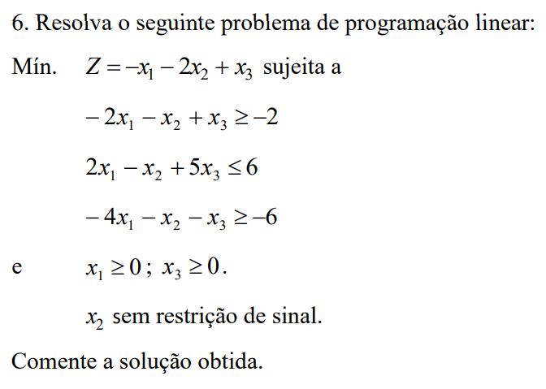

```python
from simplex import *
Image(filename='L1Q6.png')
```

```python
z = [[-1, -2, 1], [True, False, True]]
r = [[-2, -1, 1, '>=', -2],
     [2, -1, 5, '<=', 6],
     [-4, -1, -1, '>=', -6]]
```

Para utilizar o algoritmo simplex acima, nota-se que precisaremos chamar a variável $x_{2} = x_{2}' - x_{2}''$, pois ela não tem restrição de sinal. Além disso, como é um problema de minimização, utilizarei o simétrico da função objetivo para resolver o problema. Manipularei algebricamente a primeira e terceira equações restritivas a fim de deixar todas as desigualdades como sendo $\leq$. Introduzirei as variáveis de folga $x_{4}, x_{5}$ e $x_{6}$ por causa das desigualdades. Não serão necessárias variáveis artificiais visto que, após inverter a desigualdade das equações mencionadas anteriormente, nenhum dos termos independentes nos respectivos membros direitos das equações ficou negativo.

```python
m = makeMatrix(z, r, True)
printMatrix(m)
```

```
[-1, -2,  2,  1, 0, 0, 0, 0]
[ 2,  1, -1, -1, 1, 0, 0, 2]
[ 2, -1,  1,  5, 0, 1, 0, 6]
[ 4,  1, -1,  1, 0, 0, 1, 6]
```

A variável $x_{2}'$ possui o coeficiente mais negativo na primeira linha, e escolhendo a linha do fator $q=2$, teremos:

```python
makePivot(m, 1, 1)
printMatrix(m)
```

```
[-1, -2,  2,  1, 0, 0, 0, 0]
[ 2,  1, -1, -1, 1, 0, 0, 2]
[ 2, -1,  1,  5, 0, 1, 0, 6]
[ 4,  1, -1,  1, 0, 0, 1, 6]
```

```
[3, 0,  0, -1,  2, 0, 0, 4]
[2, 1, -1, -1,  1, 0, 0, 2]
[4, 0,  0,  4,  1, 1, 0, 8]
[2, 0,  0,  2, -1, 0, 1, 4]
```

Agora, é a coluna de $x_{3}$ que possui o fator mais negativo na primeira linha. Porém, percebe-se que há dois fatores $q$ válidos com o mesmo valor $2$. À priori, escolherei $x_{5}$ para sair da base:

```python
m2 = copyMatrix(m)
makePivot(m, 2, 3)
printMatrix(m)
```

```
[3, 0,  0, -1,   2,   0, 0, 4]
[2, 1, -1, -1,   1,   0, 0, 2]
[1, 0,  0,  1, 1/4, 1/4, 0, 2]
[2, 0,  0,  2,  -1,   0, 1, 4]
```

```
[4, 0,  0, 0,  9/4,  1/4, 0, 6]
[3, 1, -1, 0,  5/4,  1/4, 0, 4]
[1, 0,  0, 1,  1/4,  1/4, 0, 2]
[0, 0,  0, 0, -3/2, -1/2, 1, 0]
```

```python
printMatrix(m2)
makePivot(m2, 3, 3)
printMatrix(m2)
```

```
[3, 0,  0, -1,  2, 0, 0, 4]
[2, 1, -1, -1,  1, 0, 0, 2]
[4, 0,  0,  4,  1, 1, 0, 8]
[2, 0,  0,  2, -1, 0, 1, 4]
```

```
[3, 0,  0, -1,    2, 0,   0, 4]
[2, 1, -1, -1,    1, 0,   0, 2]
[4, 0,  0,  4,    1, 1,   0, 8]
[1, 0,  0,  1, -1/2, 0, 1/2, 2]
```

```
[4, 0,  0, 0,  3/2, 0, 1/2, 6]
[3, 1, -1, 0,  1/2, 0, 1/2, 4]
[0, 0,  0, 0,    3, 1,  -2, 0]
[1, 0,  0, 1, -1/2, 0, 1/2, 2]
```

A solução para este método foi a mesma: $$(x_{1},x_{2},x_{3})=(0,4,2)$$ Porém, precebemos que estamos em um estado diferente do encontrado anteriormente. Isto nos indica que, espacialmente falando, do estado anterior para este, percorremos outra aresta se comparado ao método anterior, porém chegamos em um ponto onde as coordenadas $x_{1}, x_{2}$ e $x_{3}$ são as mesmas.